# Physical Activity Analysis

Ram Ravichandran

June 4, 2018

## Load the Activity Data

```r
library("data.table")
df <- data.table::fread(input = "activity.csv")
```

## Exploring the Data

```r
str(df)
```

```
## Classes 'data.table' and 'data.frame':   17568 obs. of  3 variables:
##  $ steps   : int  NA NA NA NA NA NA NA NA NA NA ...
##  $ date    : chr  "2012-10-01" "2012-10-01" "2012-10-01" "2012-10-01" ...
##  $ interval: int  0 5 10 15 20 25 30 35 40 45 ...
##  - attr(*, ".internal.selfref")=<externalptr>
```

```r
summary(df)
```

```
##      steps            date              interval
##  Min.   :  0.00   Length:17568       Min.   :   0.0
##  1st Qu.:  0.00   Class :character   1st Qu.: 588.8
##  Median :  0.00   Mode  :character   Median :1177.5
##  Mean   : 37.38                      Mean   :1177.5
##  3rd Qu.: 12.00                      3rd Qu.:1766.2
##  Max.   :806.00                      Max.   :2355.0
##  NA's   :2304
```

The dataset has 17568 observations of 3 variables: steps, date, and interval. Note that the date variable is formatted as character. The step variable in the beginning few rows seems to contain many NA values. This is likley since steps will not be taken during sleep and other periods of inactivity. For proper anlaysis, these NA values should be addressed

## Total number of steps per day

```r
totalSteps <- df[, c(lapply(.SD, sum, na.rm = FALSE)), .SDcols = c("steps"), by = .(date)]
head(totalSteps)
```

```
##          date steps
## 1: 2012-10-01    NA
## 2: 2012-10-02   126
## 3: 2012-10-03 11352
## 4: 2012-10-04 12116
## 5: 2012-10-05 13294
## 6: 2012-10-06 15420
```

## Histogram of total number of steps per day

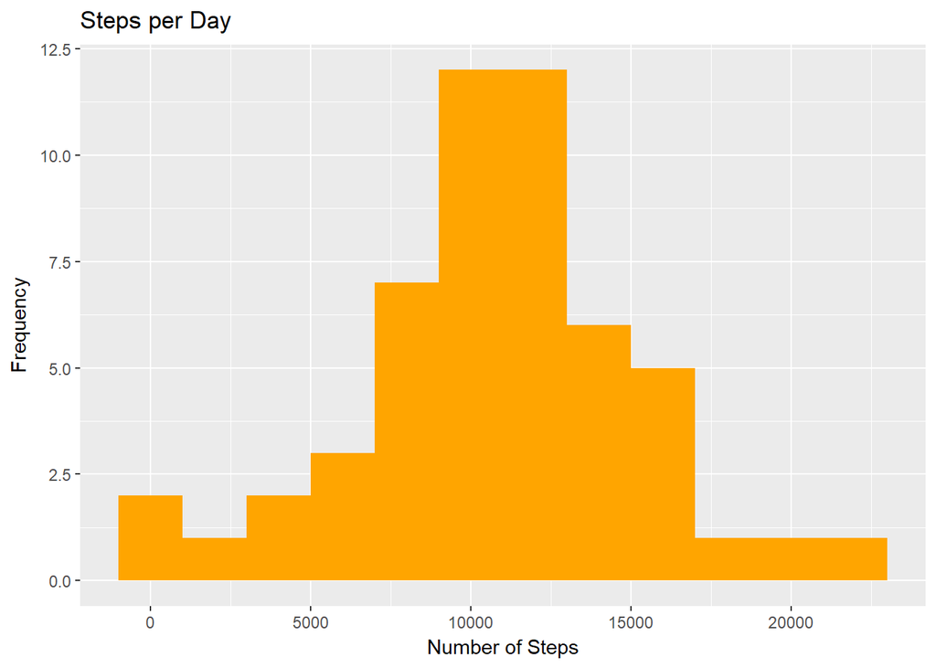

```r
library(ggplot2)
ggplot(totalSteps, aes(x = steps)) +
    geom_histogram(fill = "orange", binwidth = 2000) +
    labs(title = "Steps per Day", x = "Number of Steps", y = "Frequency")
```

## Mean and Median Steps per day

```r
meanSteps <- mean(totalSteps$steps, na.rm=TRUE)
meanSteps
```

```
## [1] 10766.19
```

```r
medianSteps <- median(totalSteps$steps, na.rm=TRUE)
medianSteps
```

```
## [1] 10765
```

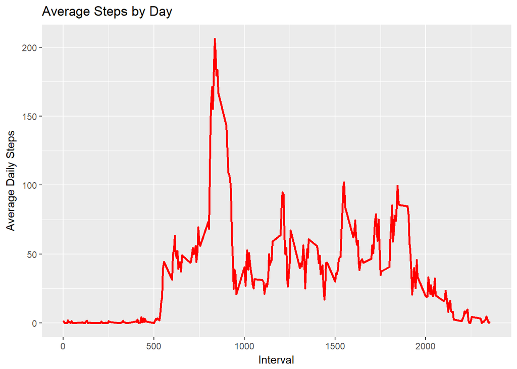

```r
intervalSteps <- df[, c(lapply(.SD, mean, na.rm = TRUE)), .SDcols = c("steps"), by = .(interval)]

ggplot(intervalSteps, aes(x = interval , y = steps)) + geom_line(color="red", size=1) + labs(title = "Average Steps by Day", x = "Interval", y = "Average Daily Steps")
```

As can be seen, the daily number of steps climber higher earlier in the day and then drops off toward the end.

## Average Daily Activity pattern

```r
intervalSteps[steps == max(steps), .(highestInterval = interval)]
```

```
##    highestInterval
## 1:             835
```

Interval 835 has the maximum number of steps.

## Imputing Missing Values

```r
missingSteps <- nrow(df[is.na(steps),])
missingSteps
```

```
## [1] 2304
```

There are 2304 missing steps.

## Imputed Dataset

A simple stratgey of replacing all missing steps with the mean value of steps will be used.

```r
dfImputedMean<- df
dfImputedMean[is.na(steps), "steps"] <- dfImputedMean[, c(lapply(.SD, mean, na.rm = TRUE)), .SDcols = c("steps")]
```

## Histogram with Imputed Values

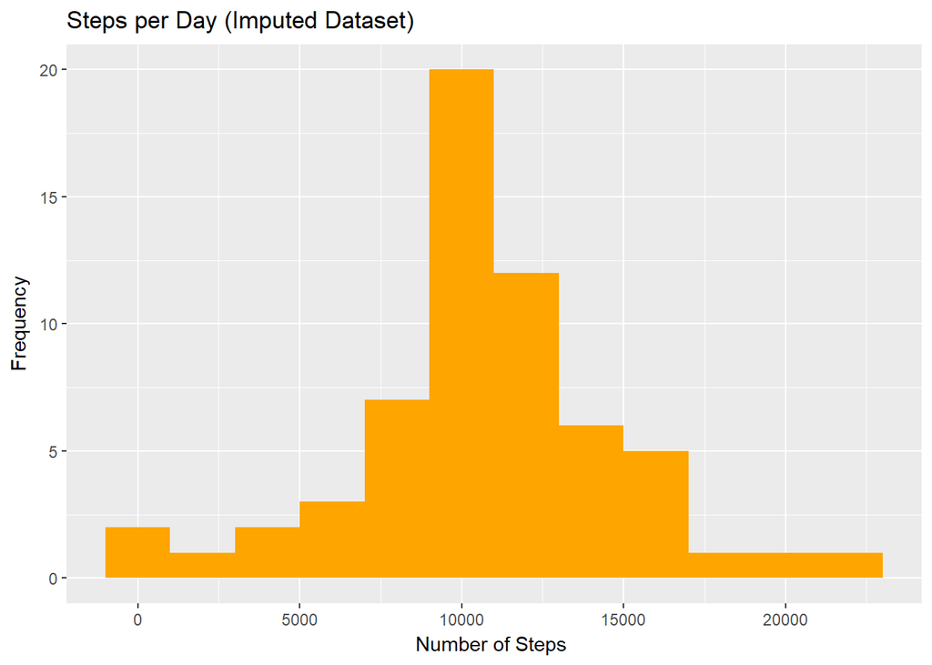

```r
totalStepsImputedMean <- dfImputedMean[, c(lapply(.SD, sum, na.rm = FALSE)), .SDcols = c("steps"), by = .(date)]
ggplot(totalStepsImputedMean, aes(x = steps)) +
    geom_histogram(fill = "orange", binwidth = 2000) +
    labs(title = "Steps per Day (Imputed Dataset)", x = "Number of Steps ", y = "Frequency")
```

## Difference between Original and Imputed Dataset

```r
meanStepsImputedMean <-  mean(totalStepsImputedMean$steps, na.rm=TRUE)
meanStepsImputedMean
```

```
## [1] 10751.74
```

```r
medianStepsImputedMean <-  median(totalStepsImputedMean$steps, na.rm=TRUE)
medianStepsImputedMean
```

```
## [1] 10656
```

```r
Mean <-   c(meanSteps,   meanStepsImputedMean )
Median <- c(medianSteps, medianStepsImputedMean)
DataSet <- c("Data with Missing Values", "Data with Imputed Values")
df_m <- data.frame(DataSet, Mean, Median)
df_m
```

```
##                    DataSet     Mean Median
## 1 Data with Missing Values 10766.19  10765
## 2 Data with Imputed Values 10751.74  10656
```

When the Imputed values are substituted, both the mean and median values go down.

## Weekdays vs Weekends

### Set up a Variable to Handle Weekday vs Weekend

```r
# Use the dataset with the imputed values
dfI <- dfImputedMean
# create a new variable called dayType
# format date variable as Date
dfI[, date := as.POSIXct(date, format= "%Y-%m-%d")]
# derive WeekDay from date
dfI[, `weekDay`:= weekdays(x = date)]
# derive DayType from WeekDay and set up as a factor
dfI[grepl(pattern = "Saturday|Sunday", x = `weekDay`), "dayType"] <- "weekend"
dfI[grepl(pattern = "Monday|Tuesday|Wednesday|Thursday|Friday", x = `weekDay`), "dayType"] <- "weekday"
dfI[, `dayType` := as.factor(`dayType`)]
# show sample rows with dayType change over
s <- dfI[5470:5475]
s
```

```
##    steps       date interval  weekDay dayType
## 1:     0 2012-10-19     2345   Friday weekday
## 2:     0 2012-10-19     2350   Friday weekday
## 3:     8 2012-10-19     2355   Friday weekday
## 4:     0 2012-10-20        0 Saturday weekend
## 5:     0 2012-10-20        5 Saturday weekend
## 6:     0 2012-10-20       10 Saturday weekend
```

As we can see above, when the Week day changes from Friday to Saturday, the dayType changes from weekday to weekend.

### Activity Differences between the work week and the weekend.

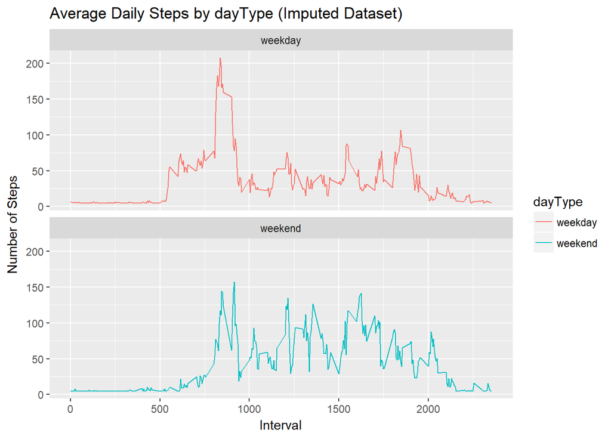

```r
intervalStepsI <- dfI[, c(lapply(.SD, mean, na.rm = TRUE)), .SDcols = c("steps"), by = .(interval, `dayType`)]

ggplot(intervalStepsI , aes(x = interval , y = steps, color=`dayType`)) + geom_line() + labs(title = "Average Daily Steps by dayType (Imputed Dataset)", x = "Interval", y = "Number of Steps") + facet_wrap(~`dayType` , ncol = 1, nrow=2)
```

The above panel shows different patterns of activity between weekday and weekends.